# Flight and Airport Analysis

December 6, 2019

## Introduction

RESEARCH QUESTIONS

- What are the most popular airlines and destinations from IAH?
- How have flight patterns out of IAH changed over time?
- How does airport quality affect the number of flights and passengers going to an airport?

## Introduction

METHODOLOGY

- Gathered and cleaned data from 5 different data sources
- Explored the data
- Created two killer plots to summarize findings

Data Gathering and Preparation

## Data Set #1

FLIGHT DATA

- 2015-2018
- Dimensions: 6,287,635 x 21
- Source: Bureau of Transportation Statistics
- Attributes: Year, month, day, day of the week, airline id, tail number, flight number, origin, origin city, dest, dest city, expected departure time, departure time, departure delay, arrival delay, cancelled (bool), carrier delay (bool), weather delay (bool)

## Data Set #2

PASSENGER DATA

- 2018
- Dimensions: 381,291 x 19
- Source: Bureau of Transportation Statistics
- Attributes: seats, passengers, unique_carrier, origin, origin_city, origin_state, dest, dest_city, dest_state, aircraft_type, class (only passenger)

## Data Set #3

REVIEWS DATA

- 2015
- Dimensions: 17,721 x 21
- Source: https://www.airlinequality.com/
- Attributes: airport_name, link, title, author, author_country, date, content, experience_airport, date_visit, type_traveller, overall_rating, queing_rating, terminal_cleanliness_rating, terminal_seating_rating, food_beverages_rating, airport_shopping_rating, wifi_connectivity_rating, airport_staff_rating, recommended

## Data Set #4

SENTIMENT DATA

- First compiled a list of the top 2,000 words across all airport reviews
- Scraped 10 synonyms for each word in the top 2,000 words from thesaurus.com
- Dimensions: 2,000 x 11
- Attributes: word, synonym1, synonym2, synonym3, synonym4, synonym5, synonym6, synonym7, synonym8, synonym9, synonym10

## Data Set #5

AIRLINE LOGO DATA

- First found the airlines that fly out of IAH
- Scraped the airline logos from travelpayouts.com
- Attributes: 12 jpeg images

Exploratory Data Analysis

## Top 20 Airport Destinations by Location

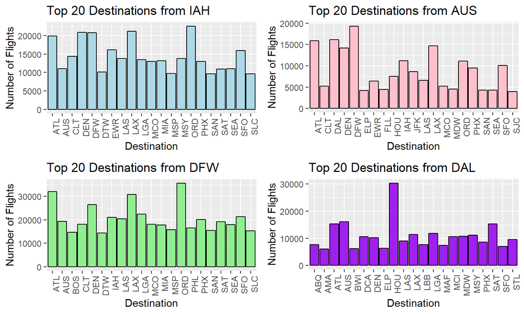

## IAH Flight and Passenger Data in 2018

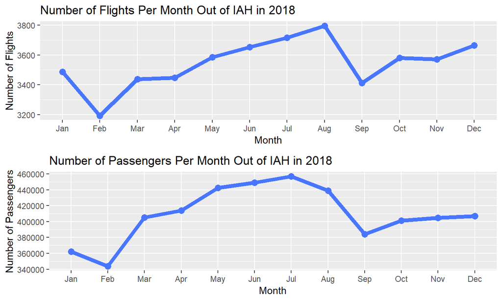

## Empty Seats for Flights Out of IAH

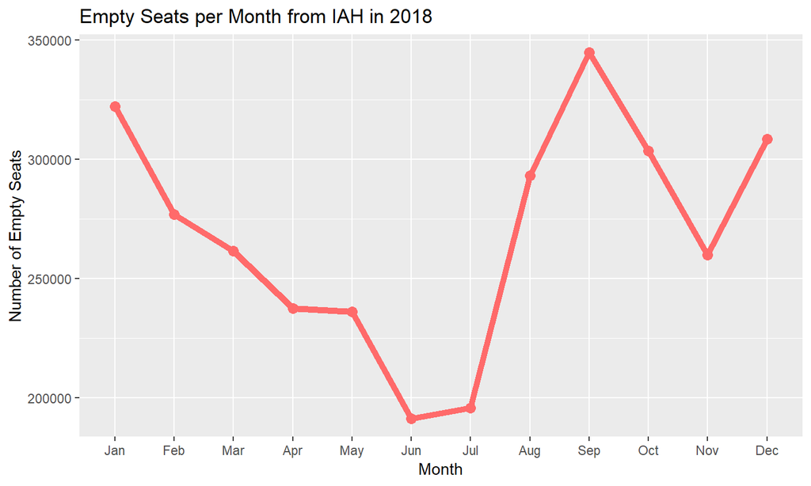

## Distribution of Airport Ratings

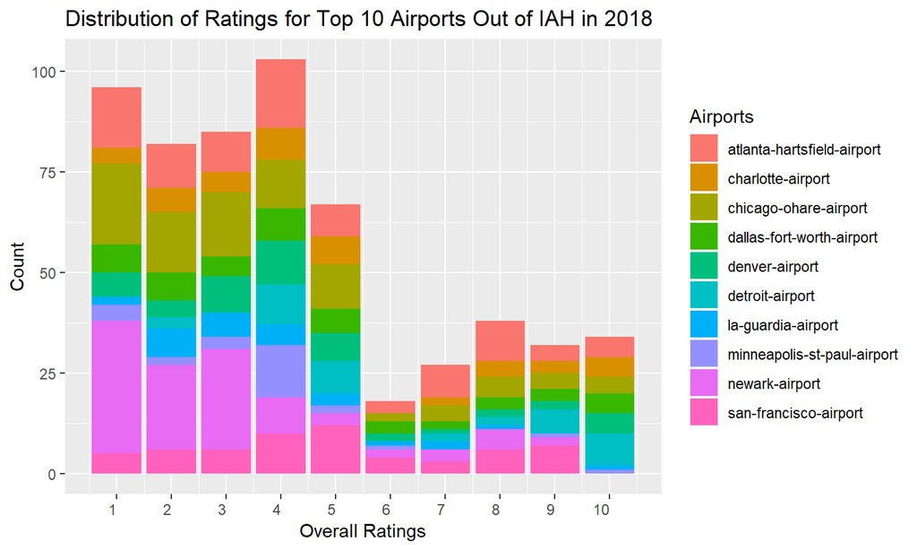

Modeling

## Sentiment Analysis

- Conducted sentiment analysis on the airport reviews
- Used synonyms we scraped from thesaurus.com for our sentiment data set in order to condense the reviews
- Used RSentiment package on these condensed reviews in order to determine if a review had a positive, neutral, or negative sentiment
- Compared our sentiment score to the average rating of the airport to analyze effectiveness of sentiment analysis

## Analyzing the Effectiveness of Sentiment Analysis

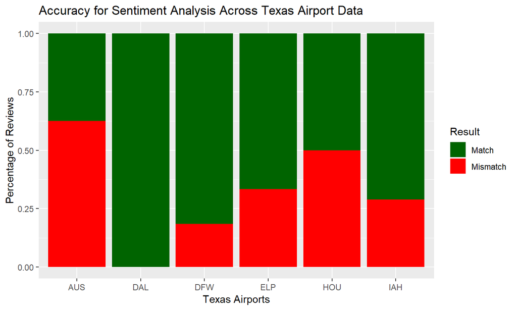

## Time Series Data

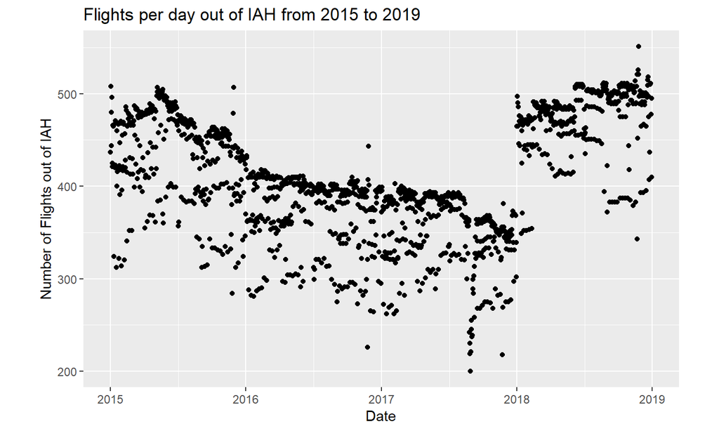

## Daily Time Series Model for Flights Out of IAH 2015-2018

[interactive chart not shown]

## Time Series Model Components

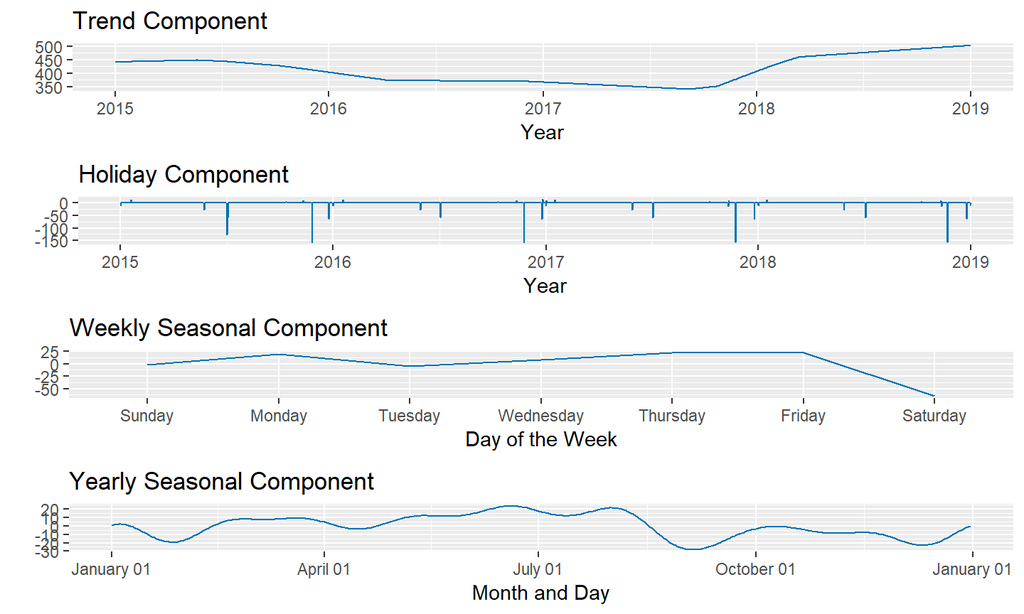

## Time Series Forecasting on Test Data

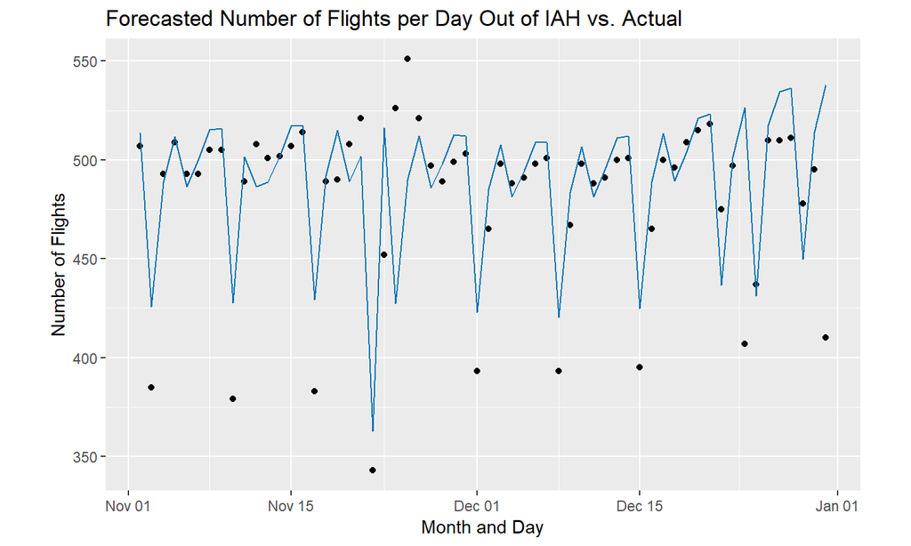

## Model Error

| Type | MAE | MAPE |
| --- | --- | --- |
| Train | 17.53556 | 0.04550617 |
| Test | 19.77747 | 0.04323118 |

Killer Plots

## Killer Plot #1

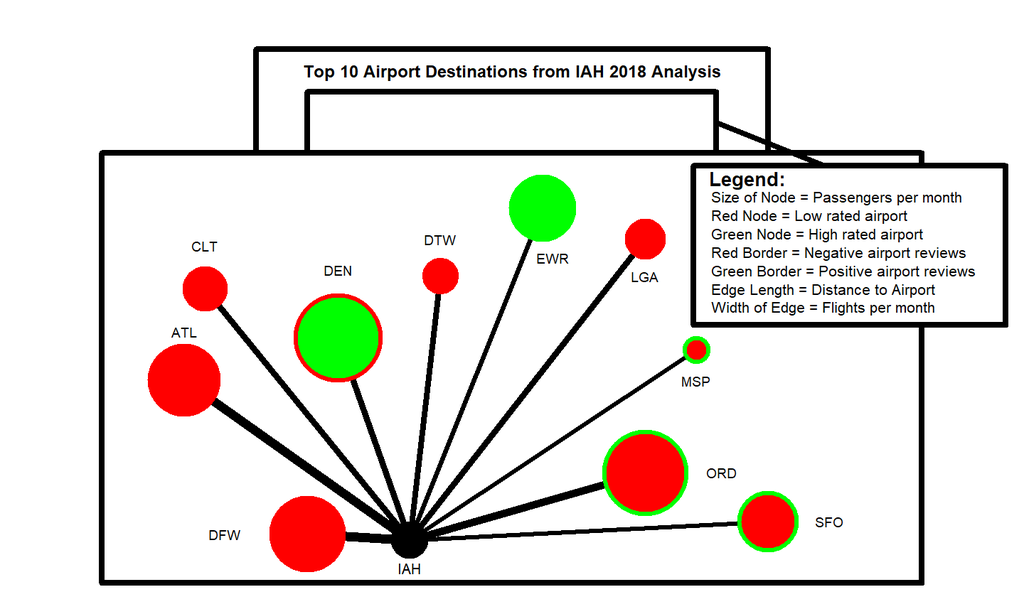

## Killer Plot #2

[figure not shown]

Conclusion

## IAH Qualitative Metrics

- Analyzed airport quality through sentiment analysis
- Visualized inefficiencies that airlines in IAH face

## IAH Time-Based Metrics

- Reinforced assumptions on seasonal effects on flight patterns
  - Summer months have the most number of flights and passengers
- Analyzed flight patterns over time through time series models
  - Visually represented flight pattern changes through killer plot
  - And predicted future flight patterns with minimal error

Thanks!

Any questions?